# Bootstrapping

지급준비금의 예측분포 산출을 위한 부트스트랩핑 기법

sonsungman https://sonsungman.github.io/SKKU-Preditive.m/  
06-02-2021

내 석사학위논문 주제인 지급준비금의 예측분포를 통한 위험조정금액 산출과 관련하여 MCMC 기법을 통한 산출은 조재훈 교수님의 2016년 논문을 중심으로 발표하였다. 또 다른 기법인 부트스트랩 기법과 관련하여서는 내가 석사학위논문 작성을 위해 엑셀 VBA를 활용하여 파일을 만들고 해당 파일을 발표할 동료 대학원생분들께 넘겨주었다. 해당 수업의 교수님께서 동료 대학원생들에게 해당 자료를 넘기라는 말씀을 하셔서 부득이하게 넘겨 주었던 기억이 난다. 나의 석사학위논문 작성을 위해 제작한 VBA자료이기 때문에 큰 부담은 없었지만 vba제작을 통해 여러측면에서 공부를 해볼 수 있다는 면에서 동료 대학원생들의 기회가 박탈된 것 아닌지 생각이 든다. 어쨋건 지급준비금의 예측분포 산출과 이를 활용한 위험조정금액 산출이라는 주제의 발표가 잘 마무리되었던 것으로 기억난다.

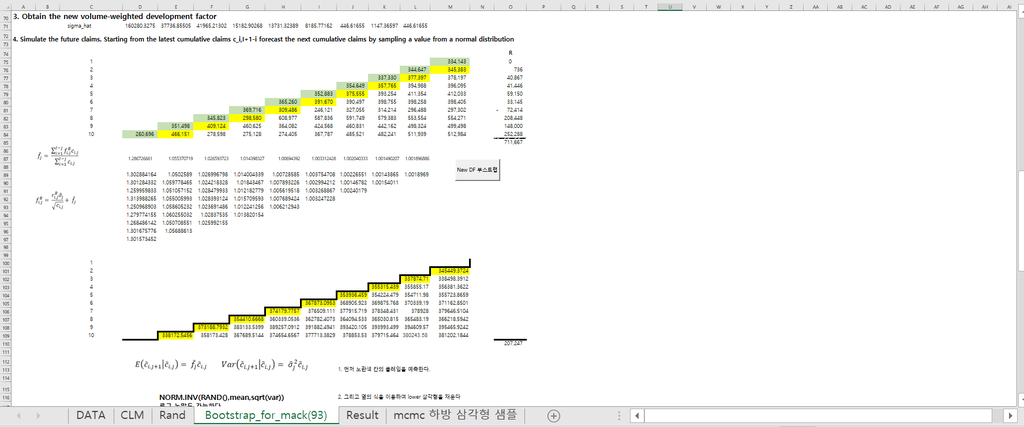

Figure 1: 부트스트랩핑 엑셀 파일

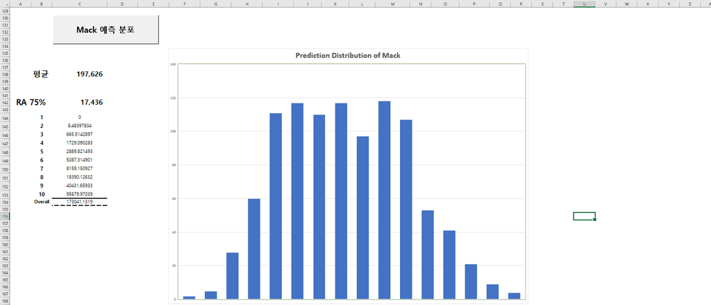

Figure 2: 부트스트랩핑 엑셀 파일

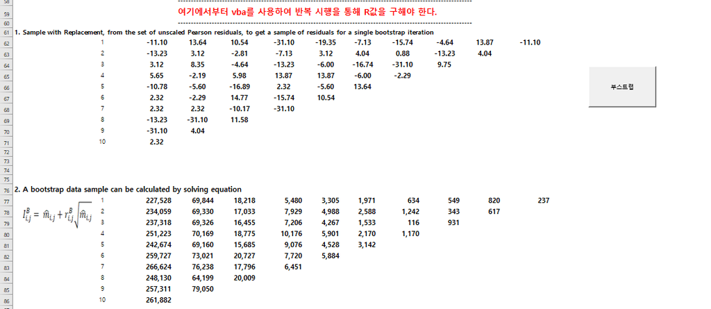

Figure 3: 부트스트랩핑 엑셀 파일

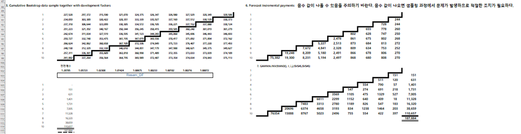

Figure 4: 부트스트랩핑 엑셀 파일

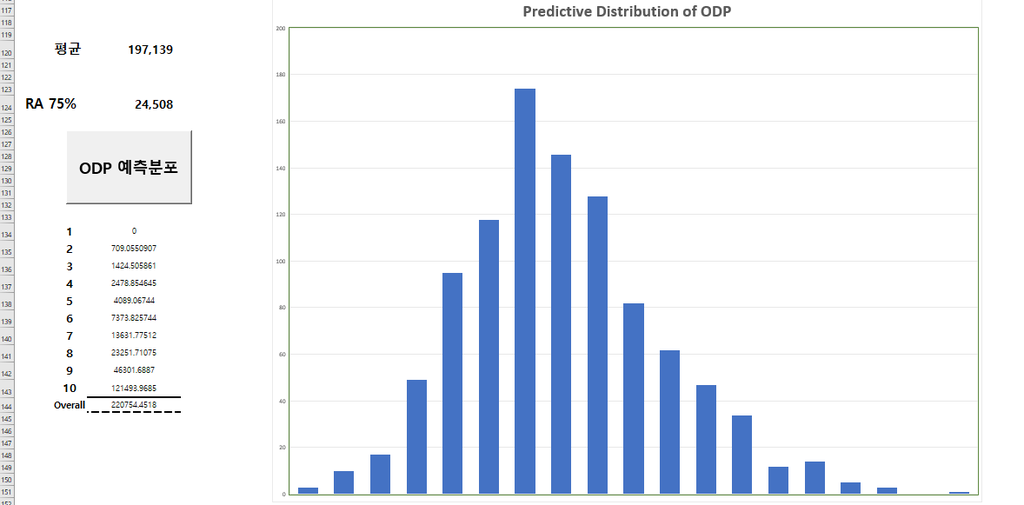

Figure 5: 부트스트랩핑 엑셀 파일

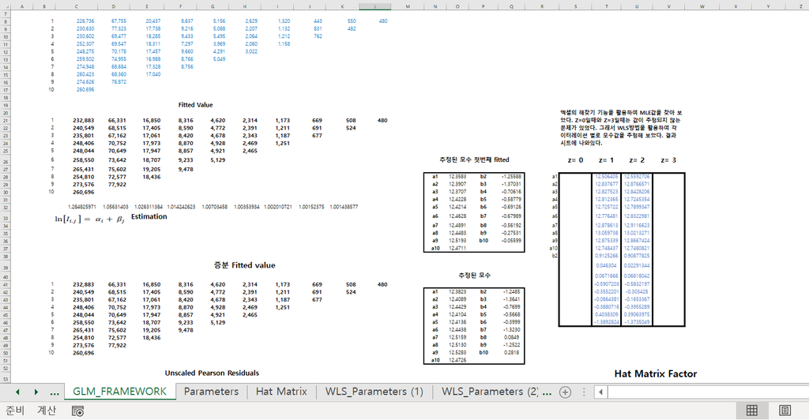

Figure 6: 부트스트랩핑 엑셀 파일

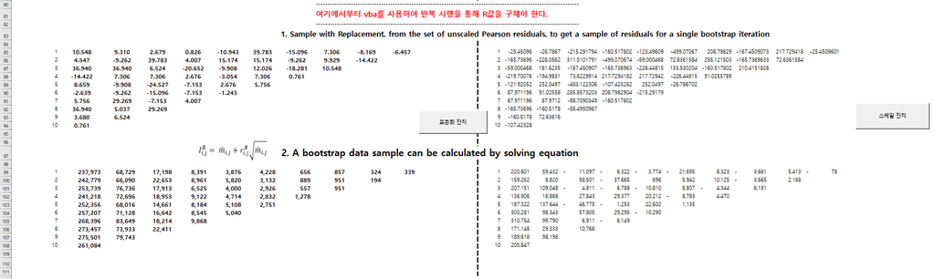

Figure 7: 부트스트랩핑 엑셀 파일

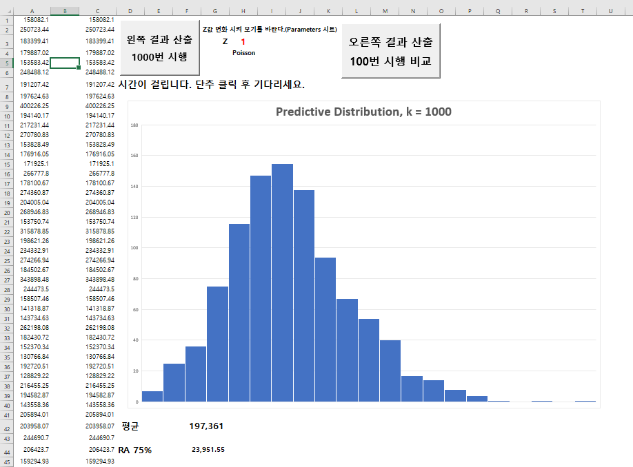

Figure 8: 부트스트랩핑 엑셀 파일

[figure not shown]